# W9 STAT5003 RMD

Victor Z. Nygaard, vnyg7406

Last compiled on 28. januar, 2023

# 1

We load in the data, and remove the ID column

```r
wine <- read_csv("../Data/winequality-data.csv",
    col_types = cols(free.sulfur.dioxide = col_integer(),
        total.sulfur.dioxide = col_integer(),
        quality = col_integer(), id = col_skip()))
wine %>% head()
```

```
## # A tibble: 6 × 12
##   fixed.acidity volatile.acidity citric.acid residual.sugar chlorides
##           <dbl>            <dbl>       <dbl>          <dbl>     <dbl>
## 1           6.7             0.15        0.38            1.7     0.037
## 2           6.7             0.44        0.31            1.9     0.03
## 3           6.1             0.17        0.21            1.9     0.09
## 4           6.6             0.39        0.22            4       0.038
## 5           6.8             0.32        0.34            6       0.05
## 6           8.3             0.28        0.27           17.5     0.045
## # … with 7 more variables: free.sulfur.dioxide <int>,
## #   total.sulfur.dioxide <int>, density <dbl>, pH <dbl>, sulphates <dbl>,
## #   alcohol <dbl>, quality <int>
```

# 2

We do $50\%$ holdout of test and training, noting first the existence of `32` missing value cases that we for lack of instruction and cardinality will simply handle via deletion.

```r
wine <- wine %>% drop_na()
wineTrainIn <- createDataPartition(wine[["quality"]], p = 0.5)[[1]]
wineTrain <- wine[wineTrainIn,]
wineTest  <- wine[-wineTrainIn,]
```

We load the `tree` package, build our decision tree as a linear composition of features and plot the result as well.

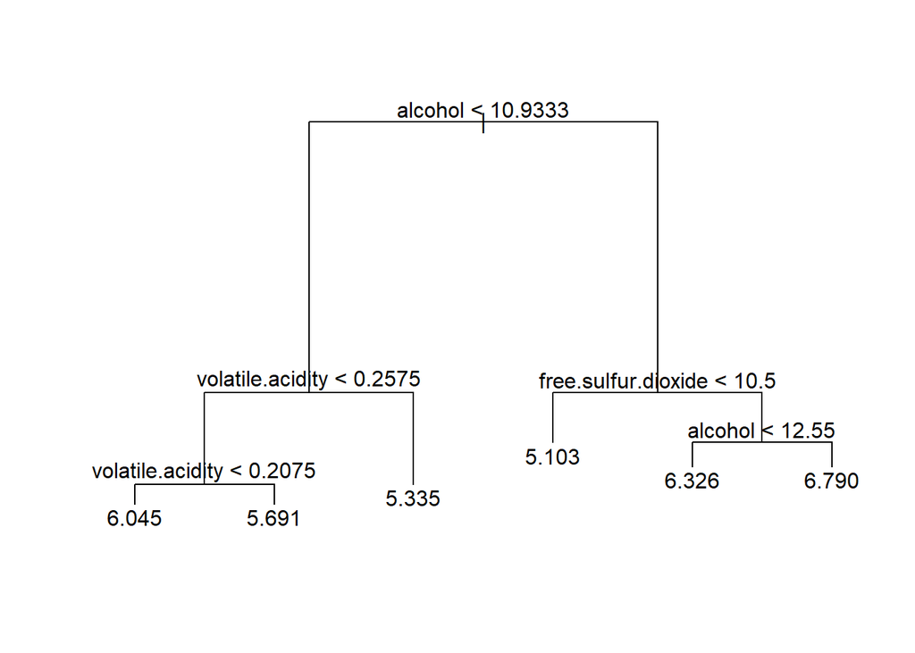

```r
#?tree
library(tree)
treeModel <- tree(quality ~ ., data = wineTrain)
plot(treeModel);text(treeModel)
```

We use the model for prediction based on the test data, and calculate the RSS

```r
treeModelPred <- predict(treeModel, newdata = wineTest)
mean((treeModelPred - wineTest$quality)^2) #RSS
```

```
## [1] 0.5760465
```

# 3

Loading and using the `ranger` package, we may train and predict a random forest model.

```r
library(ranger)
#?ranger

rfModel <- ranger(quality ~ ., data = wineTrain)
predRF <- predict(rfModel, data = wineTest)$predictions #Note that the data argument is for ranger called 'data' instead of 'newdata', and that you have to extract the predictions from the predict object under '$predictions'.
```

We may once again calculate the RSS of the present model.

```r
mean((predRF-wineTest$quality)^2)
```

```
## [1] 0.4268838
```

Which is at a lower (improved) level than for the `treeModel` above.

We write a function to train on the training data, predict on the test data, and calculate RSS of a randomForest model with `num.tree` trees

```r
RFnumtreeRSS <- function(num.tree) {
   model <- ranger(quality ~ .,  data = wineTrain, num.trees = num.tree)
   pred <- predict(model, data = wineTest)$predictions
   return(mean((wineTest$quality - pred)^2))
}
```

We may employ this functions with `num.tree` ranging from $1$ up to the default $500$ for the `ranger` package.

```r
RSSres <- sapply(1:500, RFnumtreeRSS)
```

Having calculated these, we may take the consecutive difference between the RSS entries, and find the first positive difference, corresponding to a growth of RSS. For this we use the `which` function, and remember that `diff` takes an index off, which we have to readd.

```r
(which(RSSres %>% diff() > 0) +1)[1] #which is the first num.trees for which RSS grows?
```

```
## [1] 8
```

As this first entry might be spurious, we may take a look at plotting `RSSres` along with a vertical line at the first RSS ticks upwards, and the lowest RSS

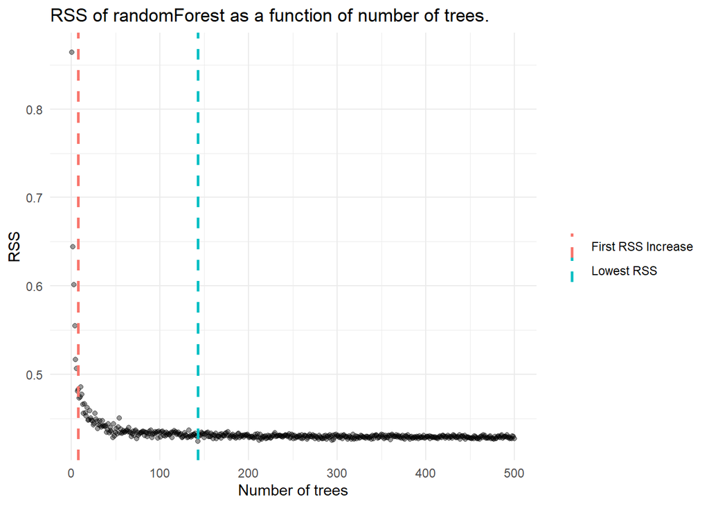

```r
RSSres_df <- data.frame(num.trees = 1:500, RSS = RSSres)
RSSres_df %>% ggplot(mapping = aes(x = num.trees, y = RSS)) + geom_point(alpha = 0.4) +
   geom_vline(mapping = aes(xintercept = (which(RSSres %>% diff() > 0) +1)[1], colour = "First RSS Increase"), linetype = "dashed", size = 1) + geom_vline(mapping = aes(xintercept = which.min(RSSres), colour = "Lowest RSS"), linetype = "dashed", size = 1) + labs(x = "Number of trees", y = "RSS", title = "RSS of randomForest as a function of number of trees.", colour = "")
```

We see that we seem to reach stability sometime later than `which(RSSres %>% diff() > 0) +1)[1]`, seemingly reaching RSS stability at around $50$ trees.

If one wanted to get the number of trees for which the randomForest has lowest RSS directly, even though this, according to the plot, might be spurious, one could use the command.

```r
which.min(RSSres)
```

```
## [1] 143
```

#4 We use gbm

```r
library(gbm)
?gbm
```

```
## starting httpd help server ... done
```

```r
form <- quality ~ .
boostModel <- gbm(formula = form, distribution = "gaussian", data = wineTrain)

pred_boostModel <- predict(boostModel, newdata = wineTest)
```

```
## Using 100 trees...
```

```r
#pred_boostModel2 <- predict(boostModel, newdata = wineTest, type = "response")
#identical(pred_boostModel, pred_boostModel2)
```

```r
mean((pred_boostModel - wineTest$quality)^2)
```

```
## [1] 0.5210678
```

```r
BoostnumtreeRSS <- function(num.tree) {
   model <- gbm(quality ~ .,  data = wineTrain, n.trees = num.tree)
   pred <- predict(model, newdata = wineTest)
   return(mean((wineTest$quality - pred)^2))
}

BoostRSS <- sapply(1:500, BoostnumtreeRSS)
```

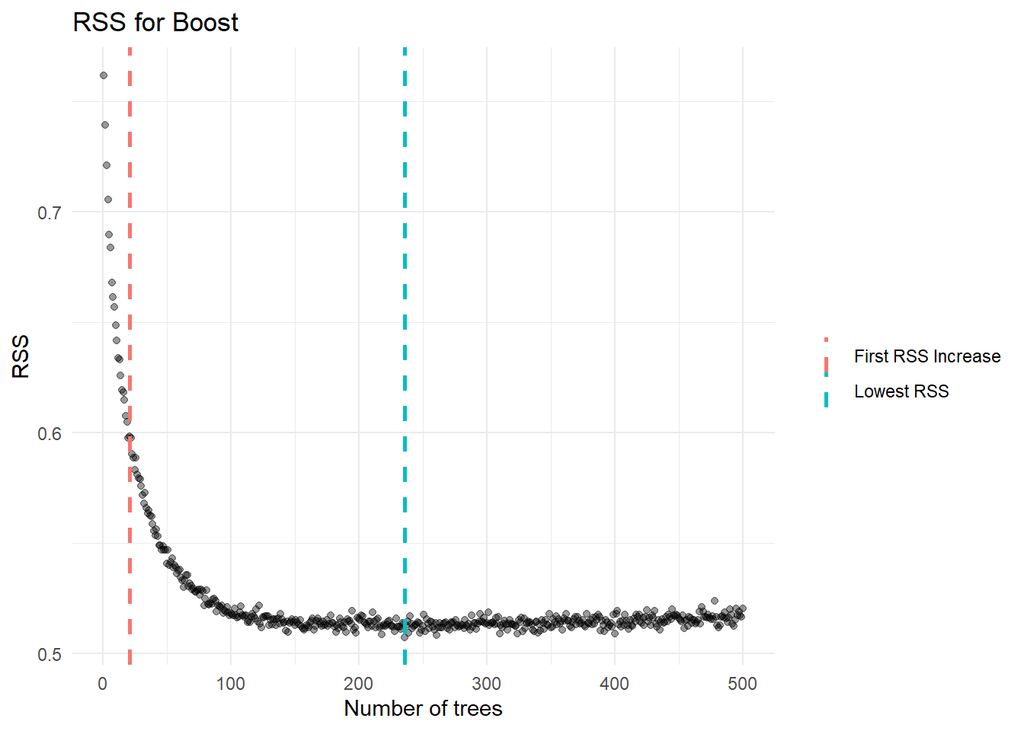

```r
BoostRSS_df <- data.frame(num.trees = 1:500, RSS = BoostRSS)
BoostRSS_df %>% ggplot(mapping = aes(x = num.trees, y = RSS)) + geom_point(alpha = 0.4) +
   geom_vline(mapping = aes(xintercept = (which(BoostRSS %>% diff() > 0) +1)[1], colour = "First RSS Increase"), linetype = "dashed", size = 1) + geom_vline(mapping = aes(xintercept = which.min(BoostRSS), colour = "Lowest RSS"), linetype = "dashed", size = 1) + labs(x = "Number of trees", y = "RSS", title = "RSS for Boost", colour = "")
```

We may try `xgboost`